# Golem

## Diagnostyka modelu - Eksperyment 1

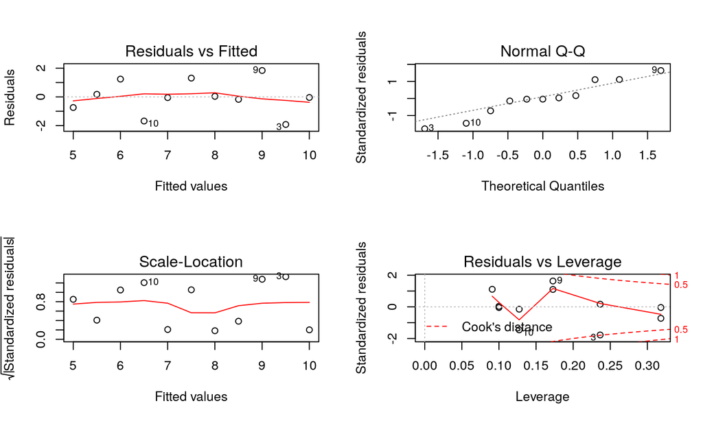

```r
par(mfrow = c(2,2))
plot(lm(y1~x1, data = anscombe))
```

## Diagnostyka modelu - Eksperyment 2

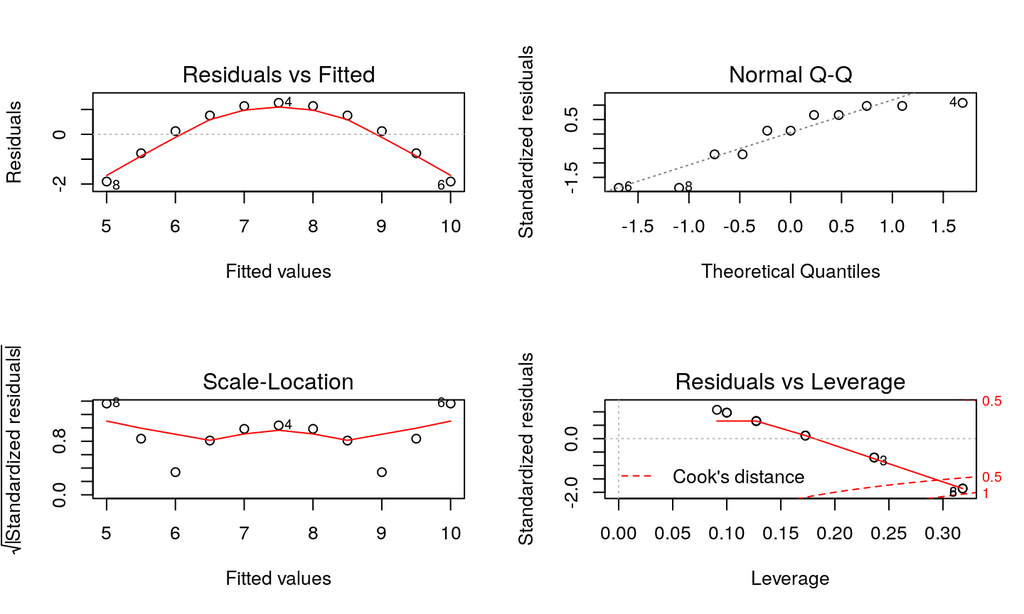

```r
par(mfrow = c(2,2))
plot(lm(y2~x2, data = anscombe))
```

## Diagnostyka modelu - Eksperyment 3

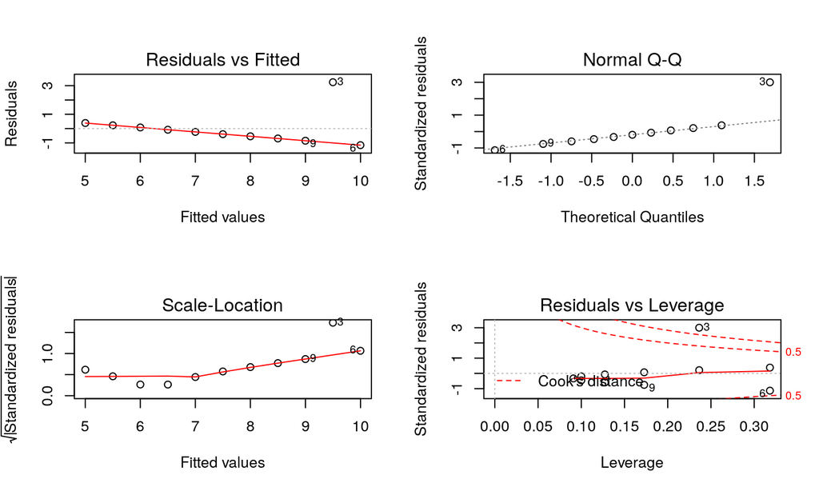

```r
par(mfrow = c(2,2))
plot(lm(y3~x3, data = anscombe))
```

## Diagnostyka modelu - Eksperyment 4

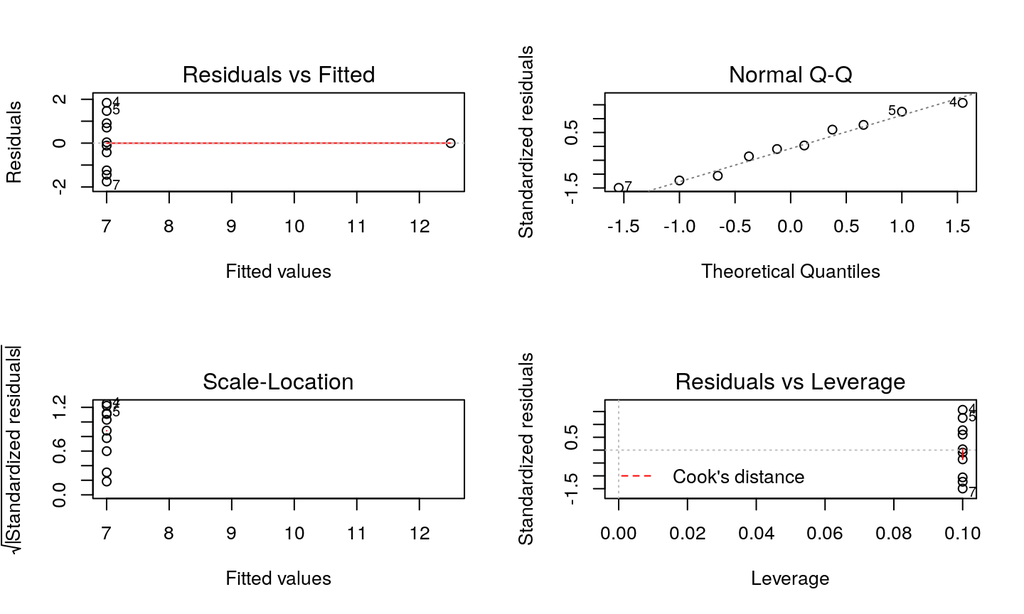

```r
par(mfrow = c(2,2))
plot(lm(y4~x4, data = anscombe))
```

## Genomy - wielkość genomu, a udział par GC

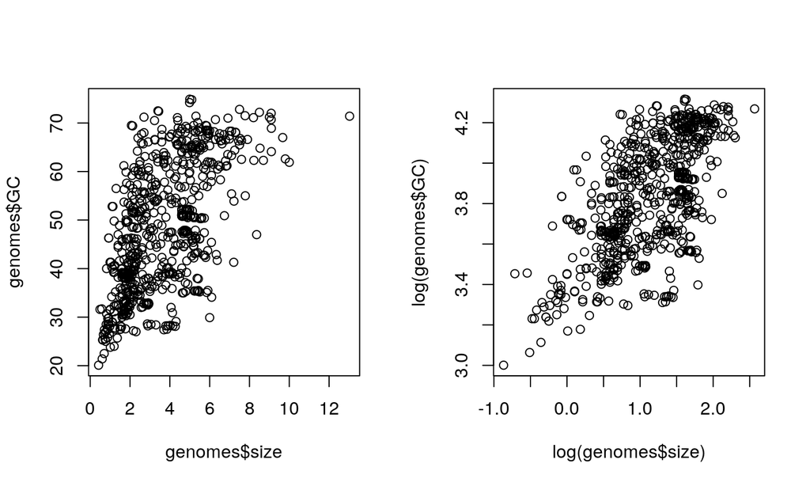

```r
library(PBImisc)
data("genomes")

par(mfrow = c(1,2))
plot(genomes$size, genomes$GC)
plot(log(genomes$size), log(genomes$GC))
```

## Genomy - model 1

```r
library(PBImisc)
data("genomes")

model1 = lm(GC ~ size, data = genomes)
summary(model1)
```

```
##
## Call:
## lm(formula = GC ~ size, data = genomes)
##
## Residuals:
##     Min      1Q  Median      3Q     Max
## -28.300  -8.217  -1.238   8.490  28.014
##
## Coefficients:
##             Estimate Std. Error t value Pr(>|t|)
## (Intercept)  32.6825     0.8235   39.69   <2e-16 ***
## size          4.2529     0.2041   20.84   <2e-16 ***
## ---
## Signif. codes:  0 '***' 0.001 '**' 0.01 '*' 0.05 '.' 0.1 ' ' 1
##
## Residual standard error: 10.38 on 722 degrees of freedom
## Multiple R-squared:  0.3755, Adjusted R-squared:  0.3746
## F-statistic: 434.1 on 1 and 722 DF,  p-value: < 2.2e-16
```

## Genomy - model 2

```r
library(PBImisc)
data("genomes")

model2 = lm(log(GC) ~ log(size), data = genomes)
summary(model2)
```

```
##
## Call:
## lm(formula = log(GC) ~ log(size), data = genomes)
##
## Residuals:
##      Min       1Q   Median       3Q      Max
## -0.64151 -0.15871 -0.00245  0.17443  0.53415
##
## Coefficients:
##             Estimate Std. Error t value Pr(>|t|)
## (Intercept)  3.48008    0.01754  198.44   <2e-16 ***
## log(size)    0.31214    0.01392   22.42   <2e-16 ***
## ---
## Signif. codes:  0 '***' 0.001 '**' 0.01 '*' 0.05 '.' 0.1 ' ' 1
##
## Residual standard error: 0.2184 on 722 degrees of freedom
## Multiple R-squared:  0.4105, Adjusted R-squared:  0.4097
## F-statistic: 502.8 on 1 and 722 DF,  p-value: < 2.2e-16
```

## Genomy - model 1 vs 2

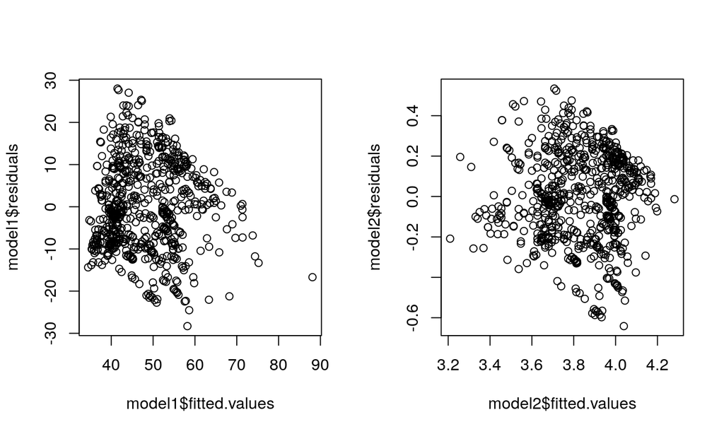

```r
par(mfrow = c(1,2))
plot(model1$fitted.values, model1$residuals)
plot(model2$fitted.values, model2$residuals)
```

## Genomy - model 3

```r
library(PBImisc)
data("genomes")

model2 = lm(log(GC) ~ log(size) + temperature, data = genomes)
summary(model2)
```

```
##
## Call:
## lm(formula = log(GC) ~ log(size) + temperature, data = genomes)
##
## Residuals:
##      Min       1Q   Median       3Q      Max
## -0.60854 -0.14021  0.00702  0.18157  0.46838
##
## Coefficients:
##              Estimate Std. Error t value Pr(>|t|)
## (Intercept) 3.3870532  0.0460237  73.594  < 2e-16 ***
## log(size)   0.3194146  0.0224079  14.255  < 2e-16 ***
## temperature 0.0025293  0.0007487   3.379 0.000801 ***
## ---
## Signif. codes:  0 '***' 0.001 '**' 0.01 '*' 0.05 '.' 0.1 ' ' 1
##
## Residual standard error: 0.2266 on 399 degrees of freedom
##   (322 observations deleted due to missingness)
## Multiple R-squared:  0.3414, Adjusted R-squared:  0.3381
## F-statistic: 103.4 on 2 and 399 DF,  p-value: < 2.2e-16
```

## Genomy - model 4

```r
library(PBImisc)
data("genomes")

model2 = lm(log(GC) ~ log(size) + temperature + habitat, data = genomes)
summary(model2)
```

```
##
## Call:
## lm(formula = log(GC) ~ log(size) + temperature + habitat, data = genomes)
##
## Residuals:
##     Min      1Q  Median      3Q     Max
## -0.5791 -0.1562  0.0071  0.1880  0.4594
##
## Coefficients:
##                          Estimate Std. Error t value Pr(>|t|)
## (Intercept)             3.4356063  0.0965069  35.600   <2e-16 ***
## log(size)               0.3189099  0.0246759  12.924   <2e-16 ***
## temperature             0.0016626  0.0008894   1.869   0.0623 .
## habitatAquatic          0.0018783  0.0863055   0.022   0.9826
## habitatHost-associated -0.0195731  0.0828236  -0.236   0.8133
## habitatMultiple        -0.0452328  0.0829004  -0.546   0.5856
## habitatSpecialized      0.0467041  0.0890887   0.524   0.6004
## habitatTerrestrial      0.0083441  0.0951015   0.088   0.9301
## ---
## Signif. codes:  0 '***' 0.001 '**' 0.01 '*' 0.05 '.' 0.1 ' ' 1
##
## Residual standard error: 0.2267 on 394 degrees of freedom
##   (322 observations deleted due to missingness)
## Multiple R-squared:  0.3491, Adjusted R-squared:  0.3375
## F-statistic: 30.18 on 7 and 394 DF,  p-value: < 2.2e-16
```

## Bibliografia

- Przemysław Biecek **Przewodnik po pakiecie R.**; GiS, 2017,
  - **Analiza danych z programem R, Modele liniowe z efektami stałymi, losowymi i mieszanymi.**; PWN, 2013,
  - **Eseje o sztuce wizualizacji danych.**; WUW, 2014,
- Murray Logan **Biostatistical design and analysis using R. A practical guide.**; Wiley-Blackwell, 2012,
- Hadley Wickham, Garrett Grolemund **R for data science: import, tidy, transform, visualize, and model data**; O’Reilly, 2017,
  - https://r4ds.had.co.nz/,
  - Hadley Wickham, Garrett Grolemund **Język R. Kompletny zestaw narzędzi dla analityków danych** Helion, 2017,
- Lander Jared P. **Język R dla każdego: zaawansowane analizy i grafika statystyczna. zaawansowane analizy i grafika statystyczna**; Promise, 2018,